# Used Cars Analysis

Cuicui Lu  
clu@seattleu.edu

# Introduction

- 25430 observations including 13 variables from craigslist US.
- Subset Data Explanation
  - Price: $500 ~ $50000
  - Age: 0 ~ 9 years
  - Cylinders: 4
  - Odometer: 0 ~ 100000
  - Fuel type: Gas
  - Type: Sedan, SUV
- 9 manufacturers from three countries been considered in the analysis:
  - DE: Audi, BMW, Mercedes-Benz (Taken as luxury cars)
  - JP: Honda, Nissan, Toyota
  - US: Chevrolet, Dodge, Ford
- Findings
  - DE cars’ prices are much higher than JP and US cars, however, they lose value fast.
  - SUV has a better performance on holding value than Sedan for most of cars.

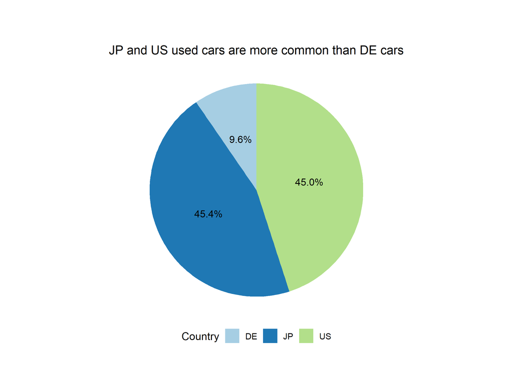

# Used cars frequency analysis

- DE cars are not very common in used cars market.
  - BMW is more popular than Audi and Mercedes.
- All the three of JP manufacturers are very popular, Nissan is the most.
- US Chevrolet and Ford have the top two highest market share.

Most of cars listed are from 3 to 6 years

| Manufacturer | 0 | 1 | 2 | 3 | 4 | 5 | 6 | 7 | 8 | 9 |
| --- | --- | --- | --- | --- | --- | --- | --- | --- | --- | --- |
| DE-Audi | NA | 12 | 37 | 58 | 40 | 21 | 31 | 18 | 22 | 13 |
| DE-BMW | 3 | 11 | 10 | 63 | 46 | 59 | 66 | 30 | 1 | NA |
| DE-Mercedes | NA | 11 | 10 | 55 | 23 | 19 | 17 | 13 | NA | NA |
| JP-Honda | 20 | 83 | 102 | 149 | 132 | 129 | 104 | 114 | 75 | 52 |
| JP-Nissan | 89 | 121 | 163 | 252 | 250 | 158 | 130 | 110 | 47 | 28 |
| JP-Toyota | 39 | 108 | 149 | 152 | 118 | 110 | 75 | 92 | 61 | 62 |
| US-Chevrolet | 62 | 165 | 176 | 220 | 222 | 232 | 134 | 118 | 85 | 29 |
| US-Dodge | 1 | 3 | 8 | 42 | 36 | 47 | 89 | 8 | 5 | 7 |
| US-Ford | 42 | 108 | 217 | 295 | 228 | 226 | 201 | 108 | 71 | 60 |

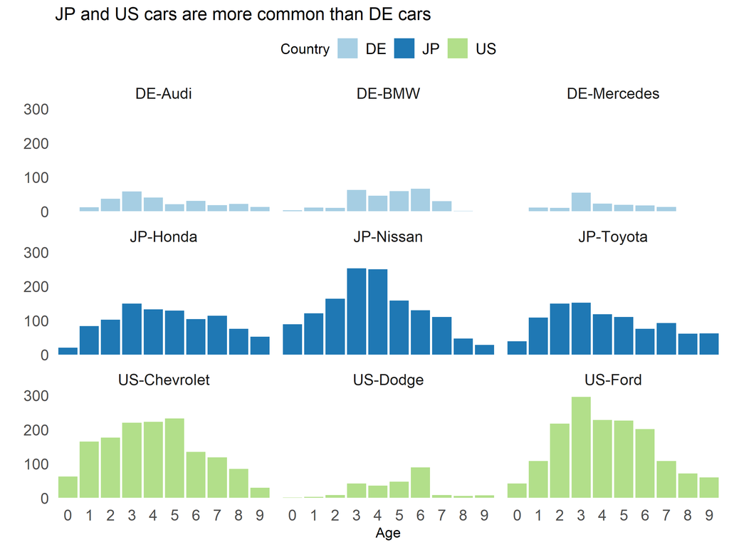

# Price change analysis

- Luxury cars’ prices are much higher than the other two overall especially for sedans.
  - The price difference for SUV is getting smaller after 4 years.
- JP cars and US cars have relatively similar prices.
  - US car’s price is the lowest in these three.

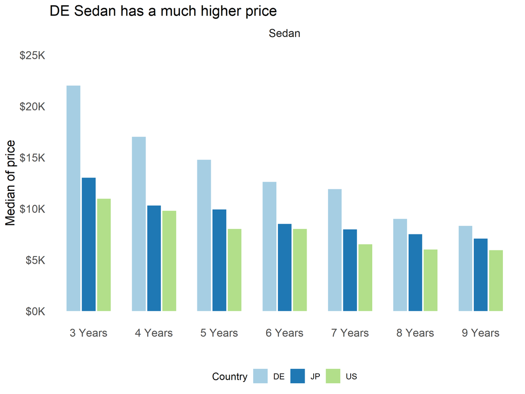

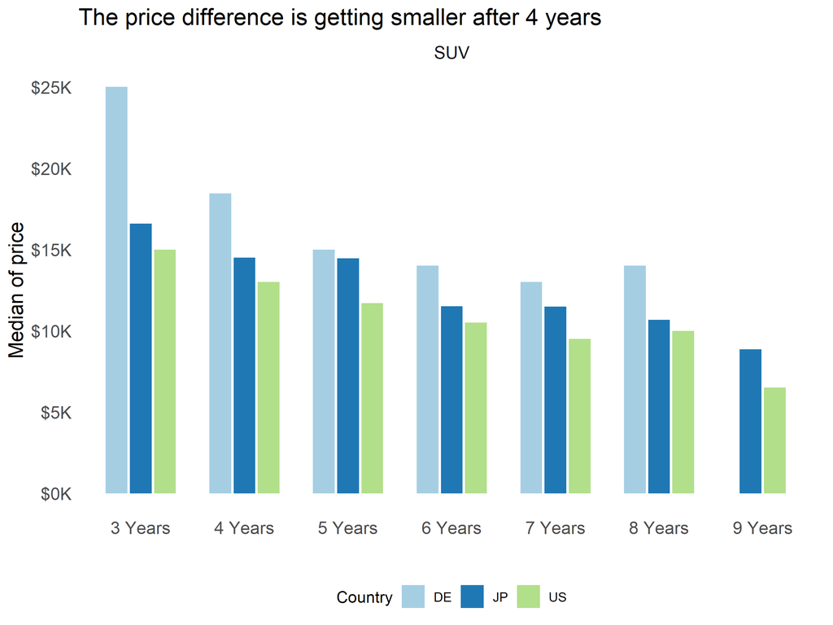

# Price reduction ratio analysis

- Japan and US sedan has similar performance on holding value.
- SUV has a better performance on holding value than Sedan.
  - US SUV holds value better than Japan before 6 years.
  - DE SUV has similar reduction ratio with the other two after 4 years.

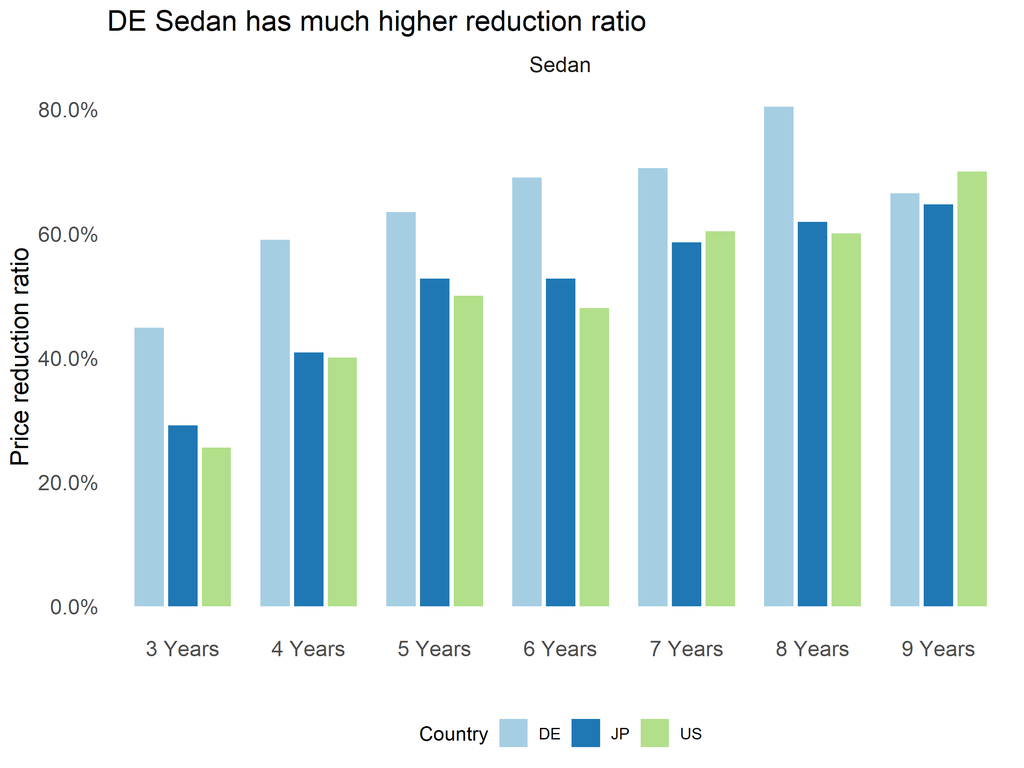

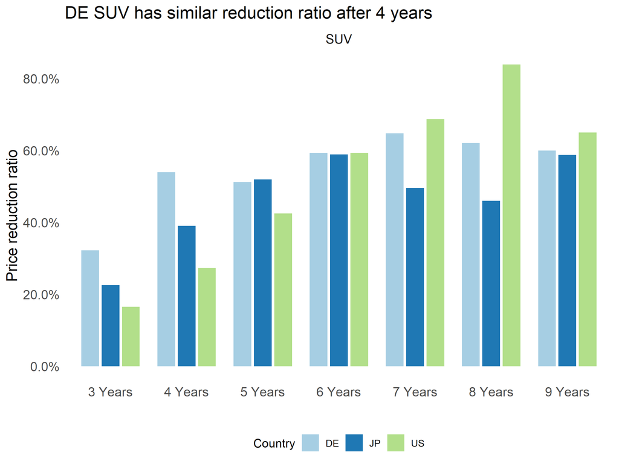

# Summary

**Conclusion**

- Luxury cars’ prices are much higher, however, they lose value fast.
  - The price difference for SUV is getting smaller after 4 years.
- US cars have lower price than JP cars and similar performance on holding value.
- SUV has a better performance on holding value than Sedan.
  - US SUV holds value better than Japan before 6 years.

**Suggestion**

- For sellers with luxury cars, I recommend not to sell them when they are pretty new since they lose a lot of value in a short time.
- For buyers interested in luxury cars, I recommend to buy SUV at around 5 years. For other buyers, I recommend to buy US cars because the price is relatively low and it also holds value very well.

*Feel free to contact me at clu@seattleu.edu for any questions.*